# Formative Assessment 11: Mixed-Design Repeated Measures ANOVA

BIO2105 - Biostatistics

Condolon, Christine Francesca A., Llaneza, Stassja Jedwig M, & Khan, Ahmad Jonathan

2026-11-22

# 1. Introduction and Research Objectives

## Research Background

In an experimental study of rat growth (Box, 1950), rats were assigned to three treatment groups: **Control** (no additive), **Thiouracil**, and **Thyroxin** administered via drinking water. Body weights were recorded across five measurement occasions: **Baseline (Week 0)** through **Week 4**.

Following an accident, three rats were removed from the Thyroxin group, leaving $N = 27$ rats and 135 total observations.

## Research Objective

To determine whether rat body weight differs significantly across treatment groups and measurement occasions, and specifically to evaluate whether growth trajectories over time depend on the treatment received (**Treatment** $\times$ Time Interaction).

# 2. Data Preparation and Exploration

```r
# 1. Load required libraries
library(nlmm)
library(tidyverse)
library(rstatix)
library(ggpubr)

# 2. Load dataset
data("rats", package = "nlmm")

# 3. Format factor variables with clear labels
rats <- rats %>%
  mutate(
    id = factor(id),
    trt = factor(
      trt,
      levels = c(1, 2, 3),
      labels = c("Control", "Thiouracil", "Thyroxin")
    ),
    time = factor(
      time,
      levels = 0:4,
      labels = c("Week 0", "Week 1", "Week 2", "Week 3", "Week 4")
    )
  )

# 4. Inspect data structure
str(rats)
```

```
## 'data.frame':    135 obs. of  4 variables:
##  $ id  : Factor w/ 27 levels "1","2","3","4",..: 1 2 3 4 5 6 7 8 9 10 ...
##  $ time: Factor w/ 5 levels "Week 0","Week 1",..: 1 1 1 1 1 1 1 1 1 1 ...
##  $ trt : Factor w/ 3 levels "Control","Thiouracil",..: 1 1 1 1 1 1 1 1 1 1 ...
##  $ y   : int  57 60 52 49 56 46 51 63 49 57 ...
```

```r
dim(rats)
```

```
## [1] 135   4
```

```r
head(rats)
```

```
##   id   time     trt  y
## 1  1 Week 0 Control 57
## 2  2 Week 0 Control 60
## 3  3 Week 0 Control 52
## 4  4 Week 0 Control 49
## 5  5 Week 0 Control 56
## 6  6 Week 0 Control 46
```

```r
table(rats$trt)
```

```
##
##    Control Thiouracil   Thyroxin
##         50         50         35
```

### Guide Question Answer

- **Why is the dataset in long format?**  
  *A long format is required because each experimental measure is observed multiple times at different times. Instead of spreading them to multiple columns (wide format) the long format stacks them into rows, where each row represents one observation at a time. Specifically, each row represents a single observation of one rat at a specific week, totaling 135 rows (27 rats × 5 weeks). Repeated-measures functions like ANOVA require this structure to partition within-subject variance across time points. The id column acts as the unique subject identifier that links all five weekly measurements back to the same individual rat, correctly accounting for the non-independence of repeated observations.*

# 3. Descriptive Statistics and Data Visualization

## 3.1 Descriptive Summary

```r
rats %>%
  group_by(trt, time) %>%
  get_summary_stats(y, type = "mean_sd")
```

```
## # A tibble: 15 × 6
##    time   trt        variable     n  mean    sd
##    <fct>  <fct>      <fct>    <dbl> <dbl> <dbl>
##  1 Week 0 Control    y           10  54    5.44
##  2 Week 1 Control    y           10  78.5  9.64
##  3 Week 2 Control    y           10 106    9.92
##  4 Week 3 Control    y           10 130.  12.6
##  5 Week 4 Control    y           10 161.  15.2
##  6 Week 0 Thiouracil y           10  54.7  4.69
##  7 Week 1 Thiouracil y           10  76.3  7.92
##  8 Week 2 Thiouracil y           10  95.8  8.50
##  9 Week 3 Thiouracil y           10 108.   9.75
## 10 Week 4 Thiouracil y           10 124   11.3
## 11 Week 0 Thyroxin   y            7  55.6  2.99
## 12 Week 1 Thyroxin   y            7  75.9  6.44
## 13 Week 2 Thyroxin   y            7 105.  11.1
## 14 Week 3 Thyroxin   y            7 133.  17.0
## 15 Week 4 Thyroxin   y            7 163.  21.5
```

## 3.2 Visualizations

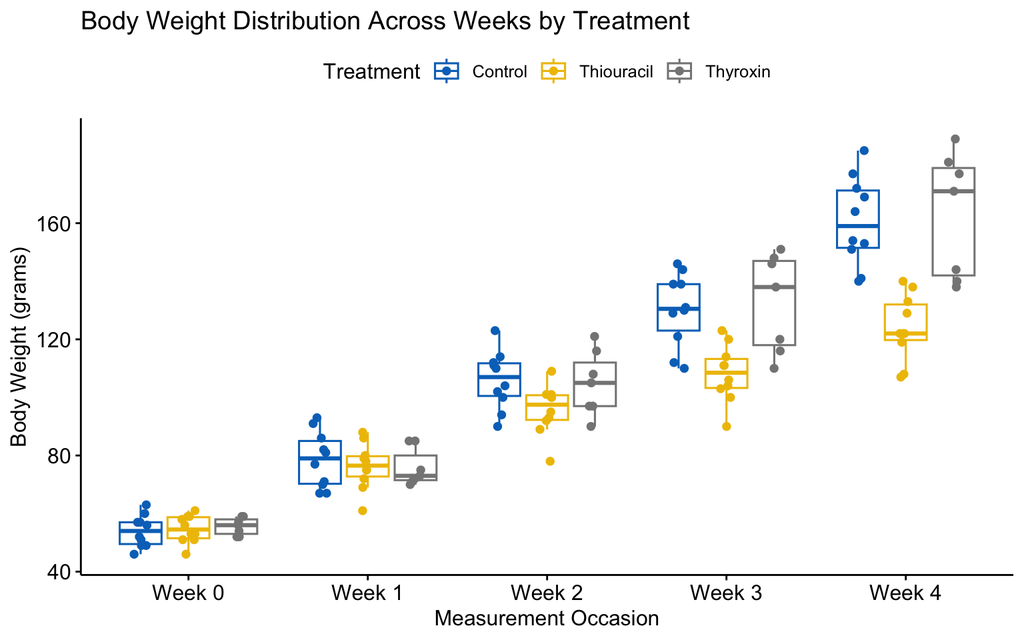

```r
# Boxplot across time points by treatment group
ggboxplot(
  rats,
  x = "time",
  y = "y",
  color = "trt",
  palette = "jco",
  add = "jitter"
) +
  labs(
    title = "Body Weight Distribution Across Weeks by Treatment",
    x = "Measurement Occasion",
    y = "Body Weight (grams)",
    color = "Treatment"
  )
```

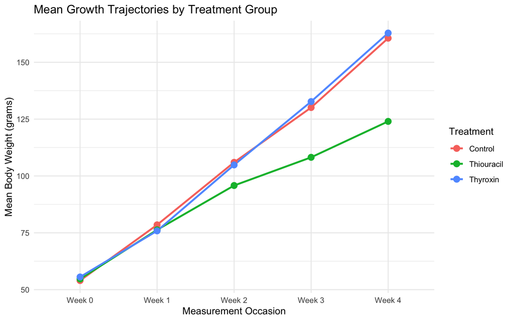

```r
# Interaction plot of mean body weights over time
rats %>%
  group_by(trt, time) %>%
  summarise(mean_weight = mean(y), .groups = "drop") %>%
  ggplot(aes(x = time, y = mean_weight, color = trt, group = trt)) +
  geom_line(linewidth = 1) +
  geom_point(size = 3) +
  labs(
    title = "Mean Growth Trajectories by Treatment Group",
    x = "Measurement Occasion",
    y = "Mean Body Weight (grams)",
    color = "Treatment"
  ) +
  theme_minimal()
```

### Guide Questions Answers

- **Baseline Highest Average:** *At Week 0, the Thyroxin group started with the highest mean body weight at 55.571 grams (SD = 2.992), followed closely by Thiouracil at 54.700 grams (SD = 4.692) and Control at 54.000 grams (SD = 5.437). The baseline differences across the three groups are relatively small (within ~1.57 grams of each other).*
- **Growth Patterns per Group:** *Both Control and Thyroxin exhibit steady, nearly linear increases in body weight over the 4-week period. Thyroxin tracks very closely with Control and grows slightly faster overall, rising from 55.571 grams at Week 0 to 162.857 grams (SD = 21.505) at Week 4, compared to Control’s rise from 54.000 grams to 160.600 grams (SD = 15.196). In contrast, Thiouracil shows a noticeably flatter growth curve—while the rats gain weight at a similar pace during Week 1 (76.300 grams), their growth rate slows down substantially by Weeks 2 through 4, reaching a much lower final mean of 124.000 grams (SD = 11.255).*
- **Visual Evidence of Interaction:** *The lines are clearly not parallel—specifically, the Thiouracil trajectory diverges downward away from the Control and Thyroxin trajectories as time progresses from Week 1 to Week 4. Non-parallel lines in an interaction plot visually indicate a Treatment x Time interaction.*

# 4. Assumption Checking

## 4.1 Normality Test (Shapiro-Wilk)

```r
# Shapiro-Wilk test per Treatment x Time combination
rats %>%
  group_by(trt, time) %>%
  shapiro_test(y)
```

```
## # A tibble: 15 × 5
##    time   trt        variable statistic      p
##    <fct>  <fct>      <chr>        <dbl>  <dbl>
##  1 Week 0 Control    y            0.960 0.791
##  2 Week 1 Control    y            0.921 0.363
##  3 Week 2 Control    y            0.978 0.951
##  4 Week 3 Control    y            0.928 0.426
##  5 Week 4 Control    y            0.954 0.715
##  6 Week 0 Thiouracil y            0.946 0.617
##  7 Week 1 Thiouracil y            0.971 0.904
##  8 Week 2 Thiouracil y            0.941 0.562
##  9 Week 3 Thiouracil y            0.978 0.955
## 10 Week 4 Thiouracil y            0.936 0.507
## 11 Week 0 Thyroxin   y            0.888 0.264
## 12 Week 1 Thyroxin   y            0.789 0.0318
## 13 Week 2 Thyroxin   y            0.960 0.815
## 14 Week 3 Thyroxin   y            0.876 0.208
## 15 Week 4 Thyroxin   y            0.860 0.152
```

## 4.2 Outlier Detection

```r
# Identify univariate extreme outliers
rats %>%
  group_by(trt, time) %>%
  identify_outliers(y)
```

```
## # A tibble: 2 × 6
##   time   trt        id        y is.outlier is.extreme
##   <fct>  <fct>      <fct> <int> <lgl>      <lgl>
## 1 Week 1 Thiouracil 19       61 TRUE       FALSE
## 2 Week 2 Thiouracil 19       78 TRUE       FALSE
```

## 4.3 Homogeneity of Variances (Levene’s Test)

```r
# Conduct Levene's test at each measurement occasion
rats %>%
  group_by(time) %>%
  levene_test(y ~ trt)
```

```
## # A tibble: 5 × 5
##   time     df1   df2 statistic     p
##   <fct>  <int> <int>     <dbl> <dbl>
## 1 Week 0     2    24     2.06  0.149
## 2 Week 1     2    24     1.18  0.326
## 3 Week 2     2    24     0.405 0.672
## 4 Week 3     2    24     1.67  0.210
## 5 Week 4     2    24     2.28  0.124
```

## 4.4 Homogeneity of Covariance Matrices (Box’s M Test)

```r
# Reshape data to wide format for Box's M test
rats_wide <- rats %>%
  pivot_wider(
    id_cols = c(id, trt),
    names_from = time,
    values_from = y,
    names_prefix = "time_"
  )

# Perform Box's M test (evaluate at alpha = 0.001)
box_m(
  rats_wide %>% select(starts_with("time_")),
  rats_wide$trt
)
```

```
## # A tibble: 1 × 4
##   statistic p.value parameter method
##       <dbl>   <dbl>     <dbl> <chr>
## 1      22.4   0.839        30 Box's M-test for Homogeneity of Covariance Matric…
```

## 4.5 Summary of Assumptions

*Assumption testing confirmed that the dataset is largely suitable for repeated-measures ANOVA, with minor adjustments required for sphericity. Specifically, normality was mostly satisfied according to Shapiro-Wilk tests (p > 0.05 across nearly all treatment-by-time combinations), with only a slight, tolerable deviation in the Thyroxin group at Week 1 (p = 0.032). Outlier detection identified two mild observations for subject id = 19 in the Thiouracil group at Weeks 1 and 2, though neither was extreme (is.extreme = FALSE), allowing all data points to be retained without transformation. Furthermore, both homogeneity of variance and homogeneity of covariance matrices were fully satisfied, as evidenced by non-significant results in Levene’s test (p = 0.124 to 0.672) and Box’s M-test (M = 22.39, p = 0.839). However, Mauchly’s test indicated a significant violation of sphericity (W = 0.011, p = 1.41 x 10^-17 for both the time main effect and the treatment-by-time interaction, necessitating the successful application of Greenhouse-Geisser and Huynh-Feldt corrections to adjust the degrees of freedom and p-values in the final ANOVA model.*

# 5. Mixed-Design Repeated Measures ANOVA

```r
# Fit mixed ANOVA
res.aov <- anova_test(
  data = rats,
  dv = y,
  wid = id,
  between = trt,
  within = time
)

# Display complete ANOVA and Sphericity output
res.aov
```

```
## ANOVA Table (type III tests)
##
## $ANOVA
##     Effect DFn DFd       F        p p<.05   ges
## 1      trt   2  24   7.884 2.00e-03     * 0.307
## 2     time   4  96 745.920 2.38e-71     * 0.910
## 3 trt:time   8  96  16.586 3.42e-15     * 0.310
##
## $`Mauchly's Test for Sphericity`
##     Effect     W        p p<.05
## 1     time 0.011 1.41e-17     *
## 2 trt:time 0.011 1.41e-17     *
##
## $`Sphericity Corrections`
##     Effect   GGe      DF[GG]    p[GG] p[GG]<.05   HFe      DF[HF]    p[HF]
## 1     time 0.342 1.37, 32.82 6.00e-26         * 0.356 1.42, 34.13 6.80e-27
## 2 trt:time 0.342 2.73, 32.82 1.73e-06         * 0.356 2.84, 34.13 1.13e-06
##   p[HF]<.05
## 1         *
## 2         *
```

```r
# Extract formatted ANOVA table
get_anova_table(res.aov)
```

```
## ANOVA Table (type III tests)
##
##     Effect  DFn   DFd       F        p p<.05   ges
## 1      trt 2.00 24.00   7.884 2.00e-03     * 0.307
## 2     time 1.37 32.82 745.920 6.00e-26     * 0.910
## 3 trt:time 2.73 32.82  16.586 1.73e-06     * 0.310
```

# 6. Post Hoc Analysis and Interaction Decomposition

## 6.1 Simple Main Effects: Treatment Differences at Each Week

```r
# One-way ANOVA per time point
rats %>%
  group_by(time) %>%
  anova_test(dv = y, wid = id, between = trt) %>%
  get_anova_table()
```

```
## # A tibble: 5 × 8
##   time   Effect   DFn   DFd      F         p `p<.05`   ges
## * <fct>  <chr>  <dbl> <dbl>  <dbl>     <dbl> <chr>   <dbl>
## 1 Week 0 trt        2    24  0.236 0.792     ""      0.019
## 2 Week 1 trt        2    24  0.266 0.769     ""      0.022
## 3 Week 2 trt        2    24  3.17  0.06      ""      0.209
## 4 Week 3 trt        2    24 10.0   0.000678  "*"     0.456
## 5 Week 4 trt        2    24 17.8   0.0000182 "*"     0.597
```

```r
# Tukey HSD pairwise comparisons per week
rats %>%
  group_by(time) %>%
  tukey_hsd(y ~ trt)
```

```
## # A tibble: 15 × 10
##    time   term  group1     group2 null.value estimate conf.low conf.high   p.adj
##  * <fct>  <chr> <chr>      <chr>       <dbl>    <dbl>    <dbl>     <dbl>   <dbl>
##  1 Week 0 trt   Control    Thiou…          0    0.700    -4.49     5.89  9.39e-1
##  2 Week 0 trt   Control    Thyro…          0    1.57     -4.15     7.29  7.74e-1
##  3 Week 0 trt   Thiouracil Thyro…          0    0.871    -4.85     6.59  9.23e-1
##  4 Week 1 trt   Control    Thiou…          0   -2.20    -11.5      7.06  8.25e-1
##  5 Week 1 trt   Control    Thyro…          0   -2.64    -12.8      7.56  7.96e-1
##  6 Week 1 trt   Thiouracil Thyro…          0   -0.443   -10.6      9.76  9.94e-1
##  7 Week 2 trt   Control    Thiou…          0  -10.2     -21.1      0.672 6.88e-2
##  8 Week 2 trt   Control    Thyro…          0   -1.14    -13.1     10.8   9.69e-1
##  9 Week 2 trt   Thiouracil Thyro…          0    9.06     -2.92    21.0   1.64e-1
## 10 Week 3 trt   Control    Thiou…          0  -21.9     -36.3     -7.47  2.48e-3
## 11 Week 3 trt   Control    Thyro…          0    2.61    -13.3     18.5   9.12e-1
## 12 Week 3 trt   Thiouracil Thyro…          0   24.5       8.61    40.4   2.14e-3
## 13 Week 4 trt   Control    Thiou…          0  -36.6     -54.2    -19.0   7.61e-5
## 14 Week 4 trt   Control    Thyro…          0    2.26    -17.2     21.7   9.55e-1
## 15 Week 4 trt   Thiouracil Thyro…          0   38.9      19.4     58.3   1.22e-4
## # ℹ 1 more variable: p.adj.signif <chr>
```

## 6.2 Simple Main Effects: Time Differences Within Each Group

```r
# Repeated measures ANOVA per treatment group
rats %>%
  group_by(trt) %>%
  anova_test(dv = y, wid = id, within = time) %>%
  get_anova_table()
```

```
## # A tibble: 3 × 8
##   trt        Effect   DFn   DFd     F        p `p<.05`   ges
##   <fct>      <chr>  <dbl> <dbl> <dbl>    <dbl> <chr>   <dbl>
## 1 Control    time    1.32 11.9   399. 5.53e-11 *       0.928
## 2 Thiouracil time    1.77 15.9   225. 4.09e-12 *       0.896
## 3 Thyroxin   time    1.15  6.91  161. 3.83e- 6 *       0.903
```

```r
# Paired t-tests between weeks with Holm correction
rats %>%
  group_by(trt) %>%
  pairwise_t_test(
    y ~ time,
    paired = TRUE,
    p.adjust.method = "holm"
  )
```

```
## # A tibble: 30 × 11
##    trt     .y.   group1 group2    n1    n2 statistic    df             p   p.adj
##  * <fct>   <chr> <chr>  <chr>  <int> <int>     <dbl> <dbl>         <dbl>   <dbl>
##  1 Control y     Week 0 Week 1    10    10     -16.0     9 0.0000000636  1.91e-7
##  2 Control y     Week 0 Week 2    10    10     -23.5     9 0.00000000217 2.17e-8
##  3 Control y     Week 0 Week 3    10    10     -21.0     9 0.00000000597 4.78e-8
##  4 Control y     Week 0 Week 4    10    10     -23.4     9 0.00000000229 2.17e-8
##  5 Control y     Week 1 Week 2    10    10     -18.3     9 0.0000000195  1.17e-7
##  6 Control y     Week 1 Week 3    10    10     -15.8     9 0.0000000726  1.91e-7
##  7 Control y     Week 1 Week 4    10    10     -19.0     9 0.0000000141  9.89e-8
##  8 Control y     Week 2 Week 3    10    10     -13.0     9 0.000000397   3.97e-7
##  9 Control y     Week 2 Week 4    10    10     -18.3     9 0.0000000202  1.17e-7
## 10 Control y     Week 3 Week 4    10    10     -18.0     9 0.0000000230  1.17e-7
## # ℹ 20 more rows
## # ℹ 1 more variable: p.adj.signif <chr>
```

# 7. APA-Style Results and Discussion

## APA Results Paragraph

> A two-way mixed-design repeated measures ANOVA was conducted to evaluate the effect of three treatment conditions (Control, Thiouracil, and Thyroxin) across five measurement occasions (Week 0 to Week 4) on rat body weight. There was a significant main effect of Treatment, $F(2, 24) = 7.88$, $p = .002$, $\eta_G^2 = 0.31$, and a significant main effect of Time, $F(1.37, 32.82) = 745.92$, $p < .001$, $\eta_G^2 = 0.91$. Crucially, the Treatment $\times$ Time interaction was statistically significant, $F(2.73, 32.82) = 16.59$, $p < .001$, $\eta_G^2 = 0.31$, indicating that body weight trajectories over time differed depending on the treatment administered. *Simple main effects analyses indicate that the treatment groups do not significantly differ during Week 0 (p = 7.92 x 10^-1), Week 1 (p = 7.69 x 10^-1), or Week 2 (p = 6.00 x 10^-2). However, significant differences between the groups emerge at Week 3 (p = 6.78 x 10^-4) and become even more pronounced at Week 4 (p = 1.82 x 10^-5), where Thiouracil significantly suppresses rat body weight compared to the Control and Thyroxin groups. Furthermore, pairwise and repeated-measures analyses across time confirm that all groups experience significant weight changes over the course of the study (Control: F = 398.811, p = 5.53 x 10^-11; Thiouracil: F = 225.074, p = 4.09 x 10^-12; Thyroxin: F = 160.945, p = 3.83 x 10^-6). While Control and Thyroxin rats maintain steady growth throughout this period, the Thiouracil group exhibits a marked plateau in weight gain during the later weeks.*.

## Central Research Question Conclusion

> **Does the effect of treatment on rat body weight depend on the measurement occasion?**  
> *Yes, the effect of treatment on rat body weight depends on the measurement occasion, as supported by the statistically significant interaction (F = 16.586, Greenhouse-Geisser corrected p = 1.73 ^-6). Biologically, this demonstrates that while all rat groups start at comparable baseline weights during the early weeks, prolonged exposure to Thiouracil suppresses normal weight gain relative to the Control and Thyroxin treatments by Weeks 3 and 4.*

# 8. References

- Box, G. E. P. (1950). Problems in the analysis of growth and wear curves. *Biometrics, 6*(4), 362–389.
- Kassambara, A. (2023). *rstatix: Pipe-Friendly Framework for Basic Statistical Tests*. R package.
- Lapointe, N. (2020). *nlmm: Generalized Linear Mixed-Effects Models*. R package dataset `rats`.